# Construcción de árboles filogenéticos no enraizados con NJ

Fernanda Rabanal e Isabel Ruiz

2025-05-28

> **Traducido y adaptado de:** *A workflow with RStudio: phylogenetic analyses and visualizations using mtDNA-Cytb sequences.* Emine TOPARSLAN, Kemal KARABAG, Ugur BILGE - June 2020

En esta práctica aprenderemos a construir un árbol filogenético no enraizado mediante el método **Neighbor Joining (NJ)**, a partir de secuencias de ADN mitocondrial (gen *Cytb*) del abejorro *Bombus terrestris dalmatinus*. Utilizaremos funciones de los paquetes `msa`, `ape`, y `ggtree`, entre otros. Elaborado en: R version 4.3.3 (2024-02-29) – *“Angle Food Cake”*.

> ⚠️ **Nota importante:** Las secuencias deben estar limpias, sin caracteres ambiguos, *gaps* o datos faltantes. Se recomienda usar secuencias previamente curadas.

### Instalación y carga de paquetes

Instalación de paquetes, en caso sea necesario

```r
#install.packages("BiocManager")
#BiocManager::install("msa")
#BiocManager::install("Biostrings")
#BiocManager::install("ggtree")

#Nota: Si está ejecutando el código por primera vez o no ha usado las bibliotecas mencionadas anteriormente, instalar las bibliotecas eliminando el símbolo de anotación "#" al inicio de cada comando.
```

```r
#install.packages("ape")
#install.packages("ggplot2")
#install.packages("pegas")

#Nota: Si está ejecutando el código por primera vez o no ha usado las bibliotecas mencionadas anteriormente, instalar las bibliotecas eliminando el símbolo de anotación "#" al inicio de cada comando.
```

Cargamos los paquetes necesarios

```r
library(Biostrings)
library(ape)         # Distancias genéticas y NJ
library(msa)         # Alineamiento múltiple
library(ggtree)      # Visualización de árboles
library(ggplot2)     # Gráficos
library(pegas)       # Agrupamiento en árboles
```

### Lectura y alineamiento de secuencias

Para leer el archivo .fasta (aún no alineado)

```r
secuencias_bumblebee <- readDNAStringSet("bumblebee.fasta", format = "fasta")
```

```r
#Visualizar nuestras secuencias
secuencias_bumblebee
```

```
## DNAStringSet object of length 120:
##       width seq                                             names
##   [1]   373 TTCCATATATTGGTCAATTTAC...CTGAATGATACTTCTTATTTGC Kumluca_6
##   [2]   373 TTCCATATATTGGTCAATTTAC...CTGAATGATACTTCTTATTTGC Kumluca_7
##   [3]   373 TTCCATATATTGGTCAATTTAC...CTGAATGATACTTCTTATTTGC Kumluca_5
##   [4]   373 TTCCATATATTGGTCAATTTAC...CTGAATGATACTTCTTATTTGC Kumluca_3
##   [5]   373 TTCCATATATTGGTCAATTTAC...CTGAATGATACTTCTTATTTGC Kumluca_28
##   ...   ... ...
## [116]   373 TTCCATATATTGGTCAATTTAC...CTGAATGATATTTCTTATTTGC Phaselis_2
## [117]   373 TTCCATATATTGGTCAATTTAC...CTGAATGATACTTCTTATTTGC Firm_32
## [118]   373 TTCCATATATTGGTCAATTTAC...CTGAATGATACTTCTTATTTGC Firm_58
## [119]   373 TTCCATATATTGGTCAATTTAC...CTGAATGATACTTCTTATTTGC Firm_78
## [120]   373 TTCCATATATTGGTCAATTTAC...CTGAATGATACTTCTTATTTGC Firm_82
```

Para alinear con MUSCLE (puede cambiarse por “ClustalW”)

```r
aligned_bumblebee <- msa(secuencias_bumblebee, method = "Muscle")
```

```r
# Mostrar el alineamiento
aligned_bumblebee
```

```
## MUSCLE 3.8.31
##
## Call:
##    msa(secuencias_bumblebee, method = "Muscle")
##
## MsaDNAMultipleAlignment with 120 rows and 373 columns
##       aln                                                  names
##   [1] TTCCATATATTGGTCAATTTACTGT...ACCTGAATGATATTTCTTATTTGC Bayatbadem_16
##   [2] TTCCATATATTGGTCAATTTACTGT...ACCTGAATGATATTTCTTATTTGC Bayatbadem_18
##   [3] TTCCATATATTGGTCAATTTACTGT...ACCTGAATGATATTTCTTATTTGC Bayatbadem_20
##   [4] TTCCATATATTGGTCAATTTACTGT...ACCTGAATGATATTTCTTATTTGC Termessos_18
##   [5] TTCCATATATTGGTCAATTTACTGT...ACCTGAATGATATTTCTTATTTGC Termessos_24
##   [6] TTCCATATATTGGTCAATTTACTGT...ACCTGAATGATATTTCTTATTTGC Termessos_26
##   [7] TTCCATATATTGGTCAATTTACTGT...ACCTGAATGATATTTCTTATTTGC Termessos_6
##   [8] TTCCATATATTGGTCAATTTACTGT...ACCTGAATGATATTTCTTATTTGC Phaselis_26
##   [9] TTCCATATATTGGTCAATTTACTGT...ACCTGAATGATATTTCTTATTTGC Phaselis_28
##   ... ...
## [113] TTCCATATATTGGTCAATTTACTGT...ACCTGAATGATACTTCTTATTTGC Aksu_8
## [114] TTCCATATATTGGTCAATTTACTGT...ACCTGAATGATACTTCTTATTTGC Firm_118
## [115] TTCCATATATTGGTCAATTTACTGT...ACCTGAATGATACTTCTTATTTGC Firm_92
## [116] TTCCATATATTGGTCAATTTACTGT...ACCTGAATGATACTTCTTATTTGC Aksu_6
## [117] TTCCATATATTGGTCAATTTACTGT...ACCTGAATGATACTTCTTATTTGC Aksu_14
## [118] TTCCATATATTGGTCAATTTACTGT...ACCTGAATGATACTTCTTATTTGC Aksu_24
## [119] TTCCATATATTGGTCAATTTACTGT...ACCTGAATGATACTTCTTATTTGC Aksu_26
## [120] TTCCATATATTGGTCAATTTACTGT...ACCTGAATGATACTTCTTATTTGC Aksu_4
##   Con TTCCATATATTGGTCAATTTACTGT...ACCTGAATGATACTTCTTATTTGC Consensus
```

Revisamos el tipo de objeto y lo convertimos a formato `DNAbin` compatible con `ape`

```r
#¿Qué clase de objeto tenemos aquí?
class(aligned_bumblebee)
```

```
## [1] "MsaDNAMultipleAlignment"
## attr(,"package")
## [1] "msa"
```

```r
aligned_bumblebee.DNAbin <- as.DNAbin(aligned_bumblebee)

class(aligned_bumblebee.DNAbin)
```

```
## [1] "DNAbin"
```

```r
#Visualizando nuestro alinemiento
aligned_bumblebee.DNAbin
```

```
## 120 DNA sequences in binary format stored in a matrix.
##
## All sequences of same length: 373
##
## Labels:
## Bayatbadem_16
## Bayatbadem_18
## Bayatbadem_20
## Termessos_18
## Termessos_24
## Termessos_26
## ...
##
## Base composition:
##     a     c     g     t
## 0.351 0.148 0.063 0.439
## (Total: 44.76 kb)
```

### Cálculo de distancias y árbol NJ

Calculamos la matriz de distancias genéticas usando el modelo K80

```r
dist_bumblebee <- dist.dna(aligned_bumblebee.DNAbin, model = "K80")
```

```r
dist_bumblebee
```

```
##               Bayatbadem_16 Bayatbadem_18 Bayatbadem_20 Termessos_18
## Bayatbadem_18   0.000000000
## Bayatbadem_20   0.000000000   0.000000000
## Termessos_18    0.021762908   0.021762908   0.021762908
## Termessos_24    0.021762908   0.021762908   0.021762908  0.000000000
## Termessos_26    0.021762908   0.021762908   0.021762908  0.000000000
## Termessos_6     0.021762908   0.021762908   0.021762908  0.000000000
## Phaselis_26     0.021762908   0.021762908   0.021762908  0.010811154
## Phaselis_28     0.021762908   0.021762908   0.021762908  0.010811154
## Phaselis_30     0.021762908   0.021762908   0.021762908  0.010811154
## Phaselis_4      0.021762908   0.021762908   0.021762908  0.010811154
## Phaselis_6      0.021762908   0.021762908   0.021762908  0.010811154
## Phaselis_8      0.021762908   0.021762908   0.021762908  0.010811154
## Geyikbayir 24   0.030102352   0.030102352   0.030102352  0.013541637
## Geyikbayir 6    0.030102352   0.030102352   0.030102352  0.013541637
## Geyikbayir_2    0.030102352   0.030102352   0.030102352  0.013541637
## Geyikbayir_26   0.030102352   0.030102352   0.030102352  0.013541637
## Geyikbayir_28   0.030102352   0.030102352   0.030102352  0.013541637
## Geyikbayir_4    0.030102352   0.030102352   0.030102352  0.013541637
## Firm_70         0.047344253   0.047344253   0.047344253  0.052884646
## Firm_86         0.047344253   0.047344253   0.047344253  0.052884646
## Bayatbadem_2    0.047037032   0.047037032   0.047037032  0.047020682
## Bayatbadem_26   0.047037032   0.047037032   0.047037032  0.047020682
## Bayatbadem_28   0.047037032   0.047037032   0.047037032  0.047020682
## Bayatbadem_4    0.047037032   0.047037032   0.047037032  0.047020682
## Bayatbadem 24   0.047037032   0.047037032   0.047037032  0.047020682
## Bayatbadem_6    0.047037032   0.047037032   0.047037032  0.047020682
## Phaselis_16     0.047037032   0.047037032   0.047037032  0.047020682
## Phaselis_2      0.047037032   0.047037032   0.047037032  0.047020682
## Firm_2          0.044251978   0.044251978   0.044251978  0.061514450
## Firm_28         0.044251978   0.044251978   0.044251978  0.061514450
## Termessos_1     0.038673515   0.038673515   0.038673515  0.055808631
## Termessos_2     0.038673515   0.038673515   0.038673515  0.055808631
## Termessos_27    0.038673515   0.038673515   0.038673515  0.055808631
## Termessos_28    0.038673515   0.038673515   0.038673515  0.055808631
## Termessos_29    0.038673515   0.038673515   0.038673515  0.055808631
## Termessos_3     0.038673515   0.038673515   0.038673515  0.055808631
## Termessos 25    0.038673515   0.038673515   0.038673515  0.055808631
## Termessos_30    0.038673515   0.038673515   0.038673515  0.055808631
## Termessos 7     0.038673515   0.038673515   0.038673515  0.055808631
```

[output cut: 2945 more lines]

```
## Firm_32
## Firm_58
## Firm_78
## Firm_82
## Aksu_10
## Aksu_12
## Firm_102
## Aksu_8
## Firm_118
## Firm_92
## Aksu_6
## Aksu_14
## Aksu_24       0.000000000
## Aksu_26       0.000000000 0.000000000
## Aksu_4        0.000000000 0.000000000 0.000000000
```

Construimos el árbol NJ

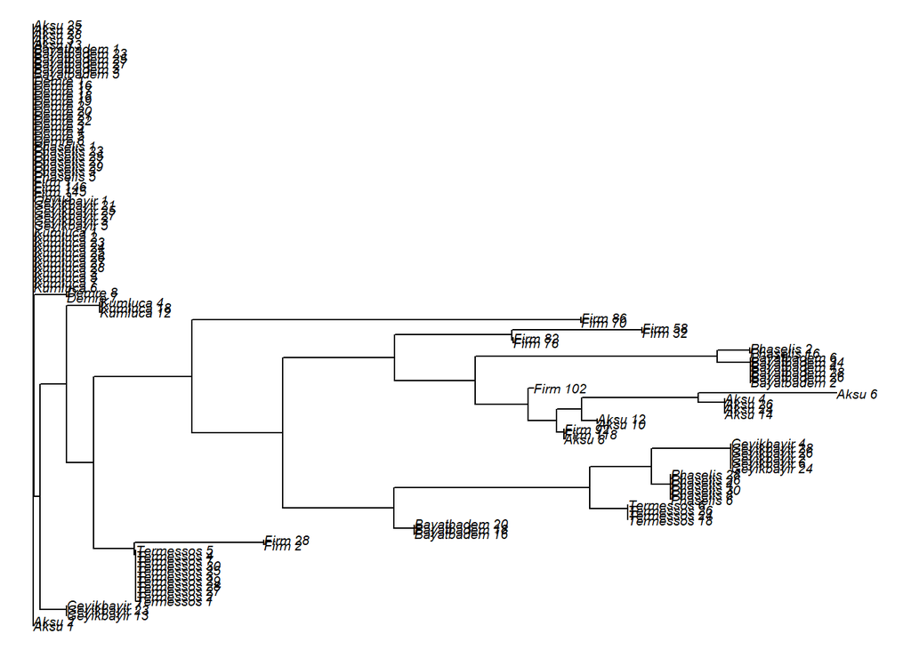

```r
tree<-nj(dist_bumblebee)

plot(tree, cex = 0.6, no.margin = TRUE)
```